# date_dead_dendro

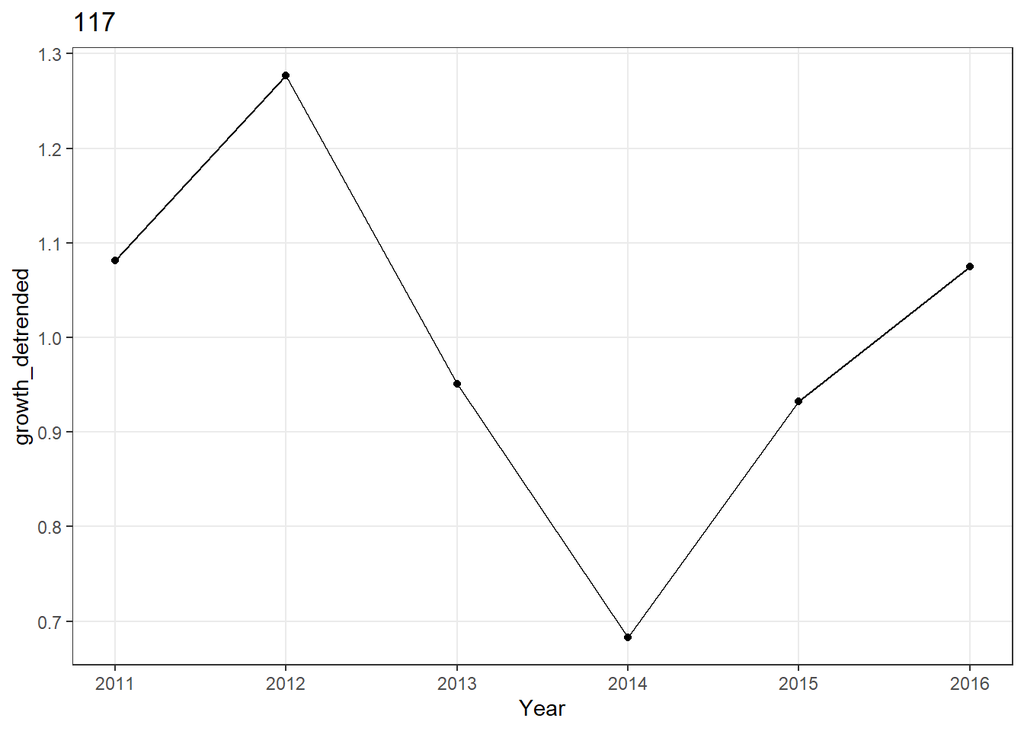

```r
add2015(80) # based on characteristics

ringplot(117)
```

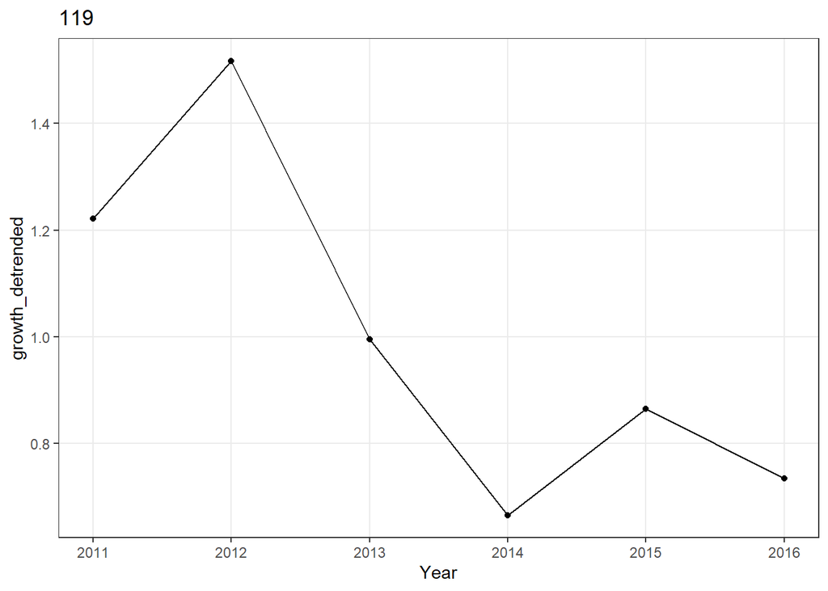

```r
add2016(117)
addsure(117)

ringplot(119)
```

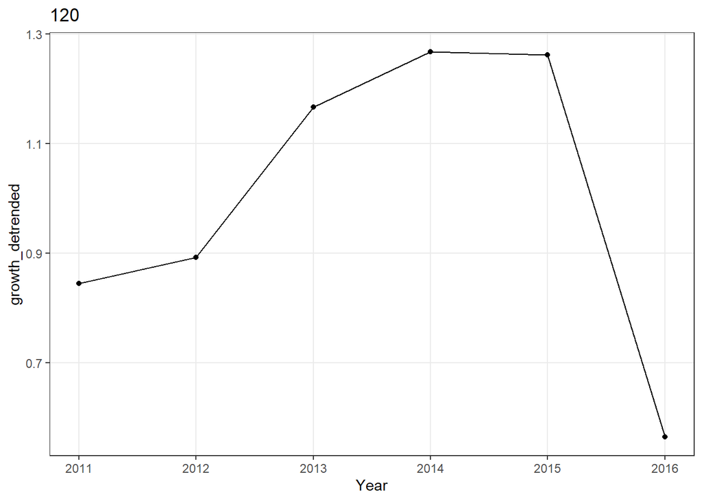

```r
add2016(119)
addsure(119)

ringplot(120)
```

```r
look(120)
```

```
##   tree HEIGHT PERC_NEEDLES NEEDLE_COLOR              BARK   BUDS Growing
## 1  120     60          0.1         grey starting to crack intact      NO
```

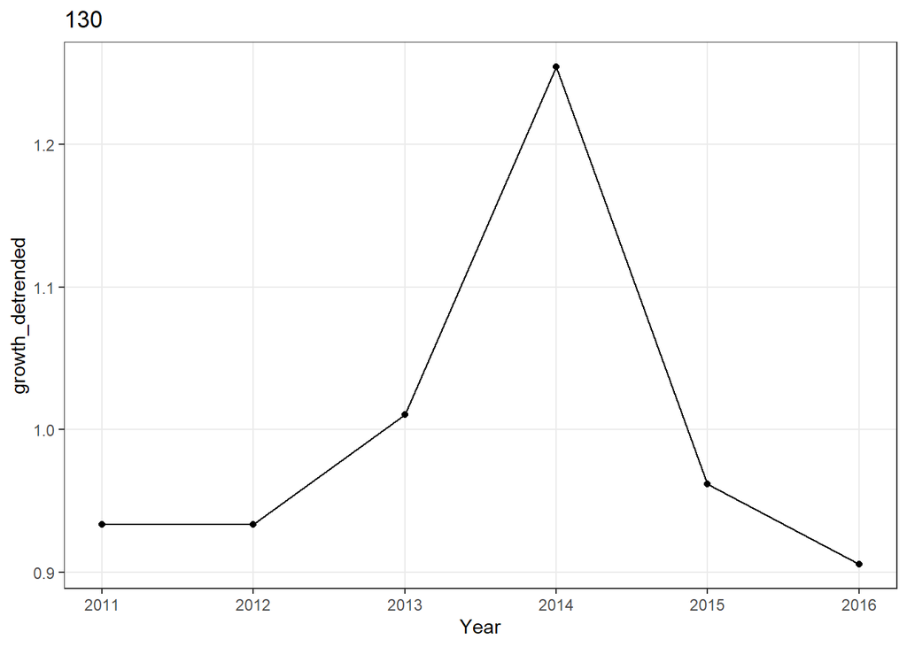

```r
add2015(120) # based largely on characteristics

ringplot(130)
```

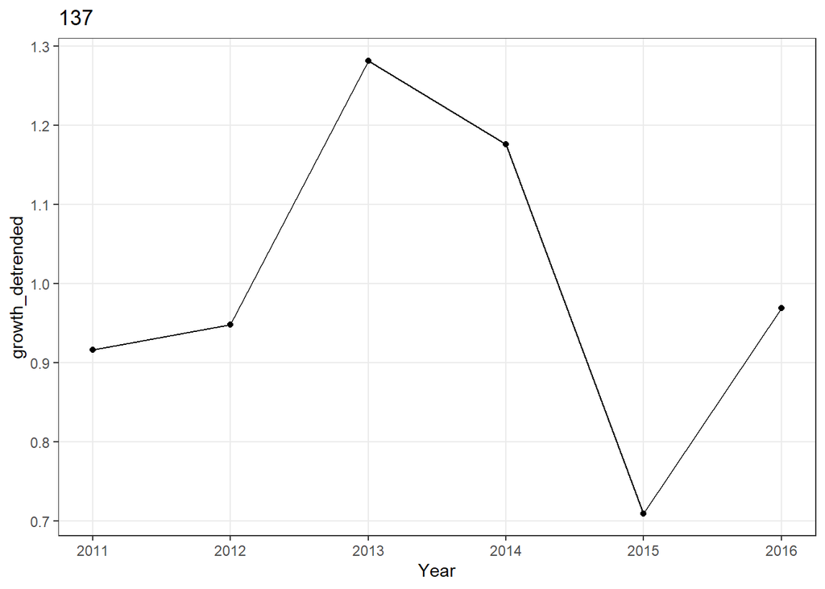

```r
addunkn(130)

ringplot(137)
```

```r
look(137)
```

```
##   tree HEIGHT PERC_NEEDLES NEEDLE_COLOR   BARK   BUDS Growing
## 1  137     73           95          red intact intact     YES
```

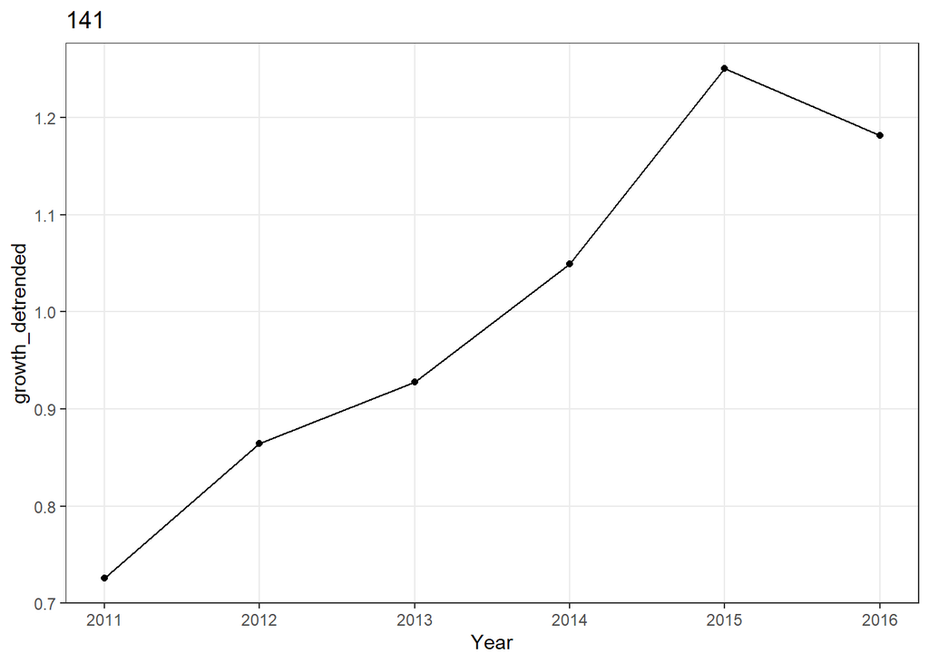

```r
add2017(137) # based largely on photo and needles and the fact that it was growing

ringplot(141)
```

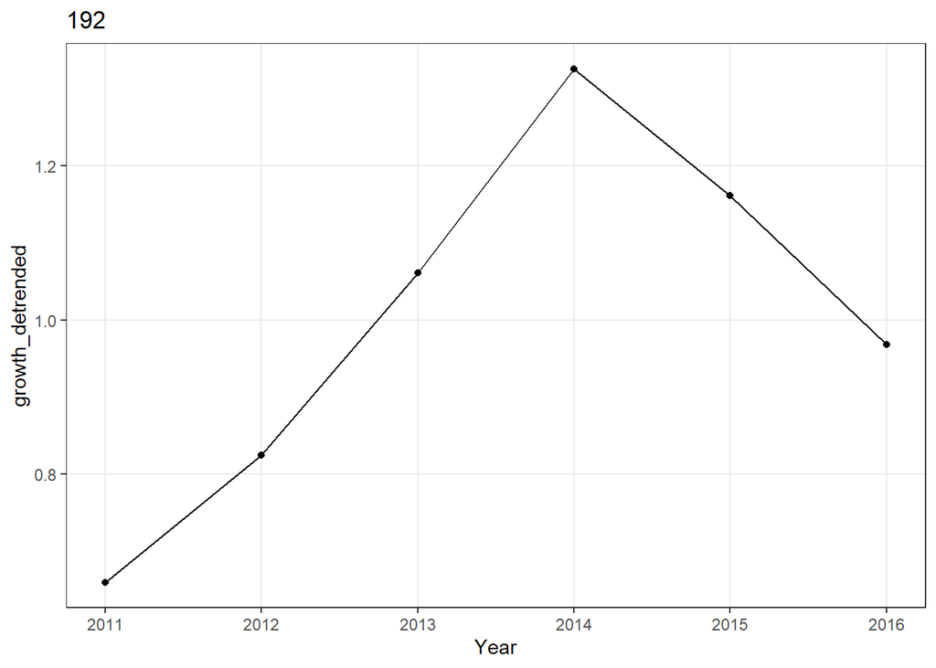

```r
addunkn(141)

ringplot(192)
```

```r
look(192)
```

```
##   tree HEIGHT PERC_NEEDLES NEEDLE_COLOR   BARK   BUDS Growing
## 1  192     56           99          red intact intact      NO
```

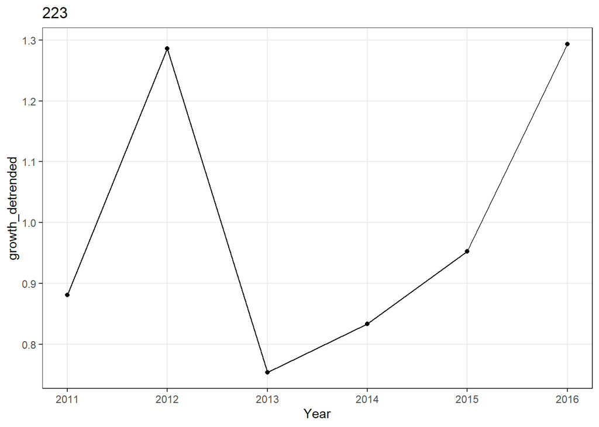

```r
add2016(192) # based on ppt

ringplot(223)
```

```r
add2017(223) # based on photo and the fact that it was growing

add2016(193) # based on ppt
```

```r
rwla2_summary_unkn[41:50,]
```

```
## # A tibble: 10 x 2
##    tree      n
##    <chr> <int>
##  1 31        6
##  2 33        6
##  3 56        6
##  4 66        6
##  5 93        6
##  6 101       5
##  7 111       5
##  8 199       5
##  9 212       5
## 10 217       5
```

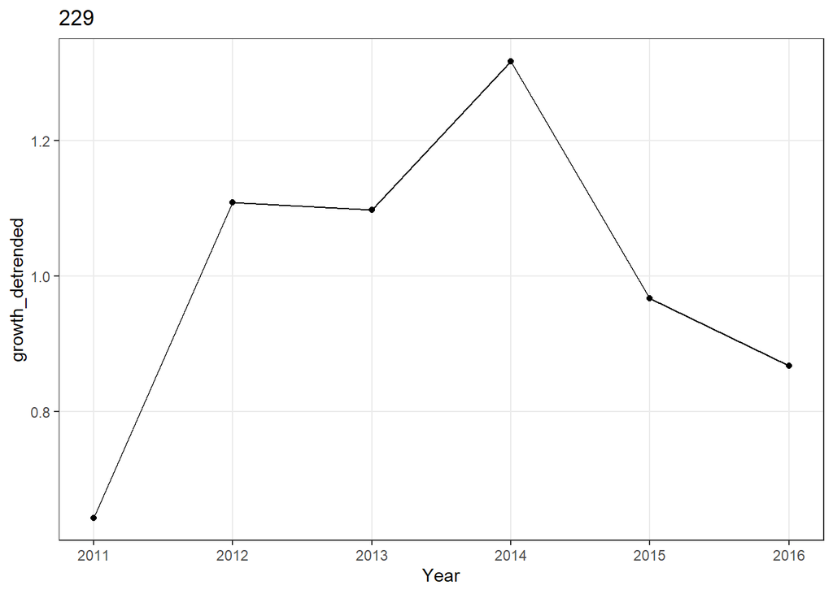

```r
add2016(47) # based on ppt

ringplot(229)
```

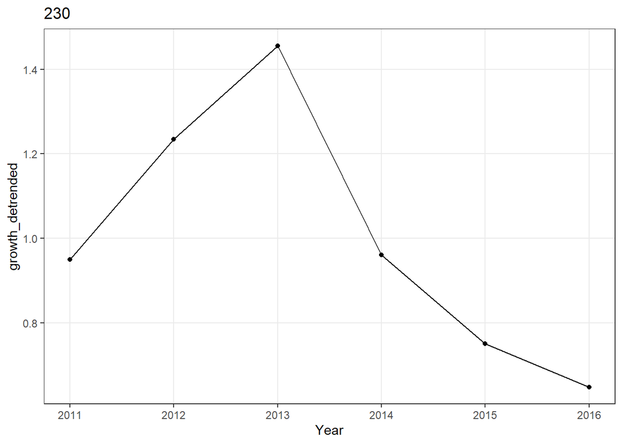

```r
addunkn(229) # maybe 2014

ringplot(230)
```

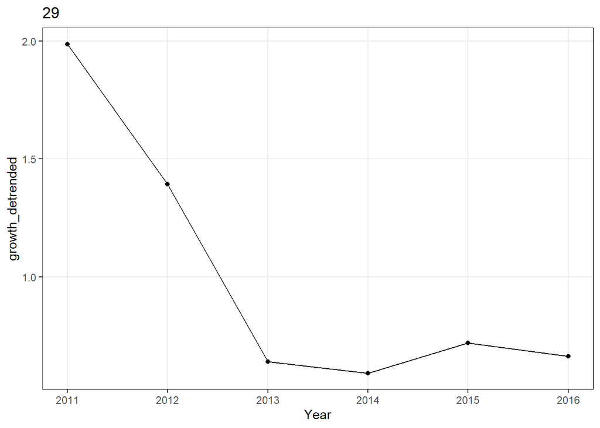

```r
add2016(230) # because of needle retention, the fact that it's not growing, and photo

ringplot(29)
```

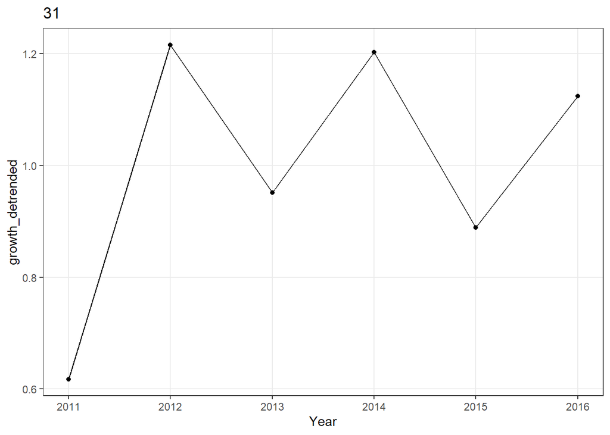

```r
add2016(29) # based largely on the fact that it's not growing and doesn't look freshly dead

ringplot(31)
```

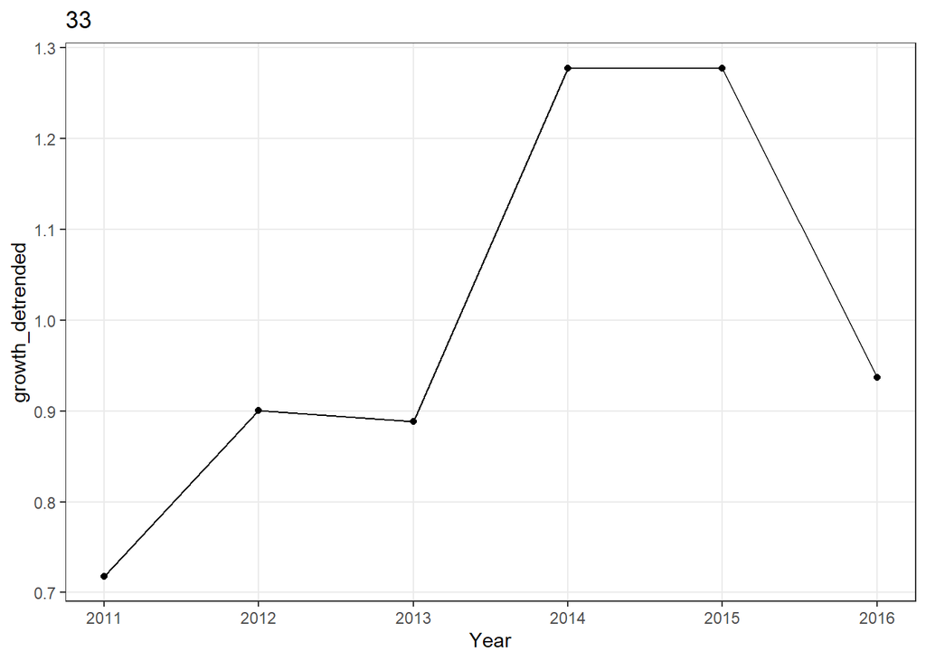

```r
add2015(31) # based largely on needle color and quantity

ringplot(33)
```

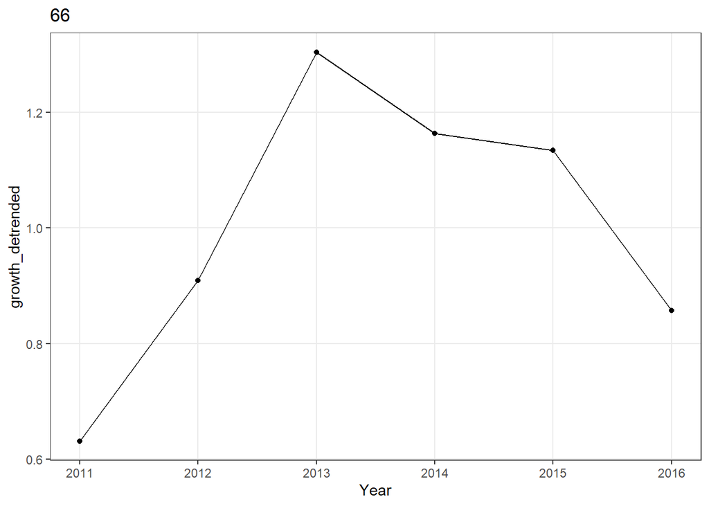

```r
add2016(33) # kind of a guess. Based largely on photo and needle retention and the fact that it's not growing

ringplot(66)
```

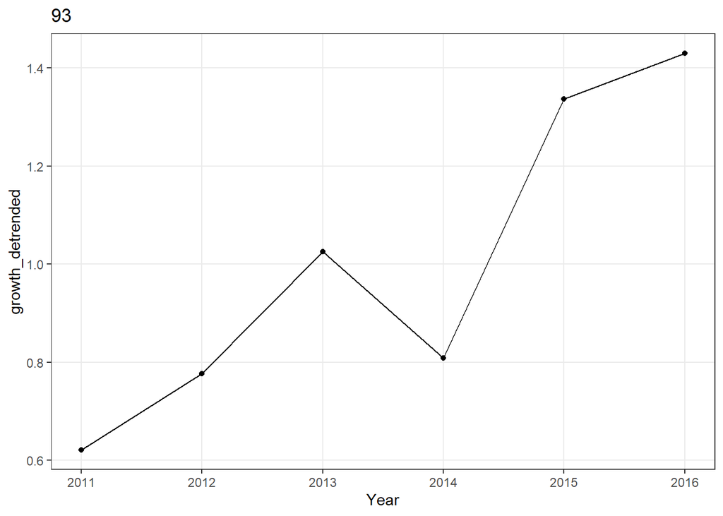

```r
add2015(66)
addsure(66)

ringplot(93)
```

```r
look(93)
```

```
##   tree HEIGHT PERC_NEEDLES NEEDLE_COLOR   BARK   BUDS Growing
## 1   93     13           99          red intact intact     YES
```

```r
add2017(93)
```

## Look at the trees I’ve added to each list

```r
died2017
```

```
##  [1] 201  55 100  30 127  16 211  32  52 169 215 208  41 161  51 112 139
## [18]  62 132 198 137 223  93
```

```r
died2016
```

```
##  [1] "68"    "78"    "102"   "131"   "4"     "184-A" "195"   "203"
##  [9] "234"   "77"    "96"    "18"    "183-A" "207"   "216"   "224"
## [17] "235"   "117"   "119"   "192"   "193"   "47"    "230"   "29"
## [25] "33"
```

```r
died2015
```

```
## [1] 128 197 214  80 120  31  66
```

```r
unkn
```

```
## [1] 129 206 130 141 229
```

```r
sure
```

```
##  [1]  41 161  78 131 203 234 132 117 119  66
```

```r
length(sure)
```

```
## [1] 10
```

### See what years the “sure” seedlings died in

```r
died2016[died2016 %in% sure]
```

```
## [1] "78"  "131" "203" "234" "117" "119"
```

```r
died2017[died2017 %in% sure]
```

```
## [1]  41 161 132
```

```r
died2015[died2015 %in% sure]
```

```
## [1] 66
```

# Summarize physical characteristics of trees that I think died in each year

```r
dfafull <- tbl_df(dfafull)
```

## 2017

```r
dfafull %>%
  dplyr::select(tree, PERC_NEEDLES, NEEDLE_COLOR, BARK, BUDS)  %>%
  filter(tree %in% died2017) %>%
  distinct
```

```
## # A tibble: 22 x 5
##    tree  PERC_NEEDLES NEEDLE_COLOR      BARK              BUDS
##    <chr> <chr>        <chr>             <chr>             <chr>
##  1 201   99           light green to o~ intact            not formed; new ~
##  2 215   50           red to light gre~ cracking in one ~ intact
##  3 198   99           red               intact            not formed; new ~
##  4 55    99           tan to light gre~ intact            intact
##  5 100   90           red to light gre~ small crack       intact
##  6 161   90           red-tan           breaking bottom ~ partial
##  7 137   95           red               intact            intact
##  8 30    25           green, tan, red   bark              intact
##  9 223   99           red               intact            intact
## 10 132   95           red               intact            intact
## # ... with 12 more rows
```

## 2016

```r
dfafull %>%
  dplyr::select(tree, PERC_NEEDLES, NEEDLE_COLOR, BARK, BUDS, Growing)  %>%
  filter(tree %in% died2016) %>%
  distinct() %>%
  arrange(PERC_NEEDLES) %>%
  arrange(Growing)
```

```
## # A tibble: 24 x 6
##    tree  PERC_NEEDLES NEEDLE_COLOR BARK         BUDS   Growing
##    <chr> <chr>        <chr>        <chr>        <chr>  <chr>
##  1 119   70           orange       intact       intact AFTER 2017 GROWTH
##  2 96    80           red          intact       intact AFTER 2017 GROWTH
##  3 78    98           reddish tan  intact       intact AFTER 2017 GROWTH
##  4 18    99           red          intact       intact AFTER 2017 GROWTH
##  5 29    80           red          intact       intact NO
##  6 235   90           red          intact       intact NO
##  7 230   90           red          intact       intact NO
##  8 33    90           red          intact       intact NO
##  9 102   90           red          small cracks intact NO
## 10 47    95           red          intact       intact NO
## # ... with 14 more rows
```

### Look at trees with 90+% needles, red, and not growing, and see if I can date them as 2016 or 2017

```r
red90notgrowing <- dfafull %>%
  filter(as.numeric(PERC_NEEDLES)>=90 & Growing == "NO" & !tree %in% c(died2017, died2016, died2015) & NEEDLE_COLOR == "red") %>%
  dplyr::select(tree, HEIGHT, PERC_NEEDLES, NEEDLE_COLOR, BARK, BUDS, Growing)  %>%
  distinct() %>%
  arrange(tree) %>%
  arrange(PERC_NEEDLES)
red90notgrowing
```

```
## # A tibble: 10 x 7
##    tree  HEIGHT PERC_NEEDLES NEEDLE_COLOR BARK             BUDS     Growing
##    <chr>  <dbl> <chr>        <chr>        <chr>            <chr>    <chr>
##  1 226       20 90           red          intact           intact   NO
##  2 36        20 90           red          intact           intact   NO
##  3 56        88 90           red          intact           intact   NO
##  4 97        17 90           red          cracking on bot~ intact   NO
##  5 218       31 95           red          intact           partial  NO
##  6 219       48 95           red          intact           intact   NO
##  7 220       35 95           red          intact           intact   NO
##  8 227       35 95           red          intact           not int~ NO
##  9 91        20 95           red          intact           intact   NO
## 10 232       48 99           red          intact           intact   NO
```

#### Add to 2017 young trees that match the characteristics of other dead 2017 trees based on data and photos

```r
add2017(232) # looks like it actually is growing
```

## 2015

```r
dfafull %>%
  dplyr::select(tree, HEIGHT, PERC_NEEDLES, NEEDLE_COLOR, BARK, BUDS, Growing)  %>%
  filter(tree %in% died2015) %>%
  distinct() %>%
  arrange(PERC_NEEDLES) %>%
  arrange(Growing)
```

```
## # A tibble: 7 x 7
##   tree  HEIGHT PERC_NEEDLES NEEDLE_COLOR BARK                 BUDS  Growing
##   <chr>  <dbl> <chr>        <chr>        <chr>                <chr> <chr>
## 1 120       60 0.1          grey         starting to crack    inta~ NO
## 2 197       58 1            grey         cracking at base an~ part~ NO
## 3 80        50 1            gray brown   intact               inta~ NO
## 4 128       72 1            gray         cracking over 15 cm  part~ NO
## 5 214       77 10           grey         missing over 5 cm n~ inta~ NO
## 6 31        89 2            gray brown   peeling on 15%       inta~ NO
## 7 66        83 50           brown        intact               inta~ NO
```

### Look if it makes sense to say all trees with <=50% needles are 2015, and then do that

```r
needles50 <- dfafull %>%
  filter(PERC_NEEDLES <=50 & !tree %in% died2017 & !tree %in% died2016  & !tree %in% died2015 ) %>%
  dplyr::select(tree, PERC_NEEDLES, NEEDLE_COLOR, BARK, BUDS)  %>%
  arrange(PERC_NEEDLES) %>%
  distinct()
needles50
```

```
## # A tibble: 10 x 5
##    tree  PERC_NEEDLES NEEDLE_COLOR BARK                              BUDS
##    <chr> <chr>        <chr>        <chr>                             <chr>
##  1 37    1            gray         cracking over 100%                intact
##  2 141   1            tan          intact                            intact
##  3 79    1            gray brown   peeling on 1%                     intact
##  4 130   1            gray         crackng everywhere, missing from~ parti~
##  5 217   10           gray/red     intact                            inact
##  6 129   2            tan          intact                            parti~
##  7 228   2            gray         cracking                          parti~
##  8 206   3            gray         cracked in 2 places               parti~
##  9 231   40           red/gray     lightly cracking over 14 cm       intact
## 10 229   5            gray         cracking                          intact
```

```r
died2015 <- c(died2015, needles50$tree)
died2015
```

```
##  [1] "128" "197" "214" "80"  "120" "31"  "66"  "37"  "141" "79"  "130"
## [12] "217" "129" "228" "206" "231" "229"
```

# Look at trees that haven’t yet been categorized

```r
dfa <- tbl_df(dfa)
dfa %>%
  filter(!tree  %in% died2017 & !tree %in% died2016 & !tree %in% died2015) %>%
  dplyr::select(tree) %>%
  distinct() %>%
  arrange()
```

```
## # A tibble: 18 x 1
##    tree
##    <chr>
##  1 222
##  2 56
##  3 101
##  4 111
##  5 199
##  6 212
##  7 218
##  8 219
##  9 225
## 10 226
## 11 227
## 12 91
## 13 97
## 14 210
## 15 220
## 16 233
## 17 36
## 18 221
```

```r
length(unique(dfa$tree))
```

```
## [1] 82
```

## Go through each one and assign a year to it

### 222

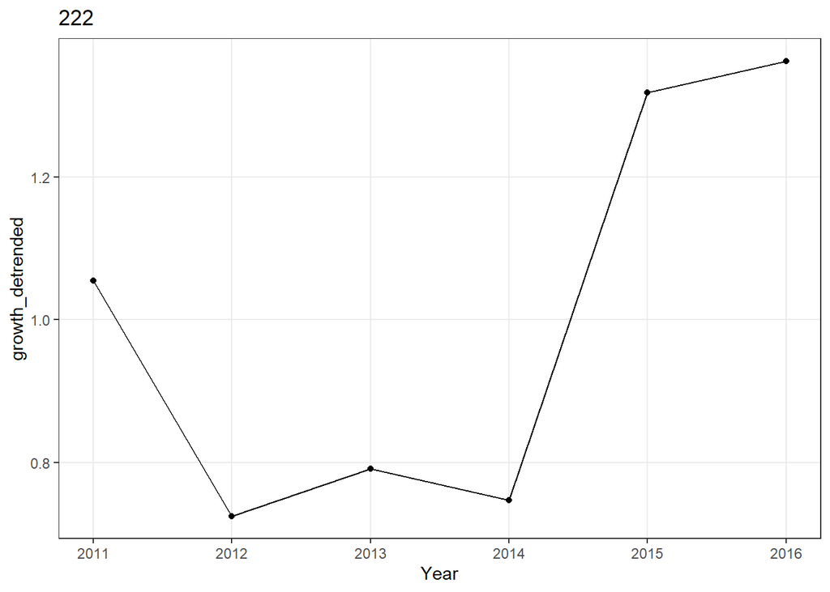

```r
ringplot(222)
```

```r
look(222)
```

```
## # A tibble: 1 x 7
##   tree  HEIGHT PERC_NEEDLES NEEDLE_COLOR BARK   BUDS   Growing
##   <chr>  <dbl> <chr>        <chr>        <chr>  <chr>  <chr>
## 1 222       19 99           red          intact intact YES
```

```r
add2017(222) # based on ppt
```

### 101

```r
look(101)
```

```
## # A tibble: 1 x 7
##   tree  HEIGHT PERC_NEEDLES NEEDLE_COLOR BARK   BUDS  Growing
##   <chr>  <dbl> <chr>        <chr>        <chr>  <chr> <chr>
## 1 101       47 90           red          intact none  YES
```

```r
add2017(101)
```

### 111

```r
look(111)
```

```
## # A tibble: 1 x 7
##   tree  HEIGHT PERC_NEEDLES NEEDLE_COLOR BARK         BUDS   Growing
##   <chr>  <dbl> <chr>        <chr>        <chr>        <chr>  <chr>
## 1 111       38 80           red          cracking 20% intact YES
```

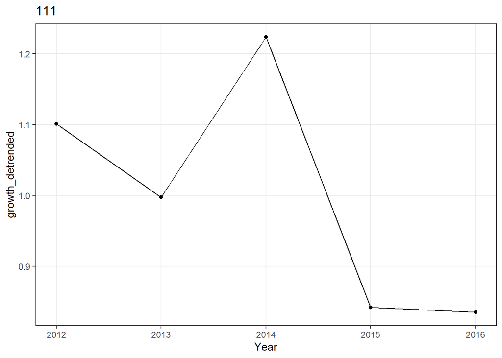

```r
ringplot(111)
```

```r
add2016(111)
```

### 199

```r
look(199)
```

```
## # A tibble: 1 x 7
##   tree  HEIGHT PERC_NEEDLES NEEDLE_COLOR BARK   BUDS                Growing
##   <chr>  <dbl> <chr>        <chr>        <chr>  <chr>               <chr>
## 1 199       45 90           red          intact not formed; new gr~ YES
```

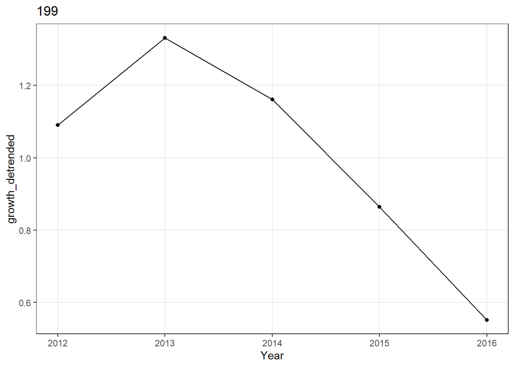

```r
ringplot(199)
```

```r
add2016(199)
```

### 212

```r
look(212)
```

```
## # A tibble: 1 x 7
##   tree  HEIGHT PERC_NEEDLES NEEDLE_COLOR BARK   BUDS                Growing
##   <chr>  <dbl> <chr>        <chr>        <chr>  <chr>               <chr>
## 1 212       36 99           red to tan   intact not formed; new gr~ YES
```

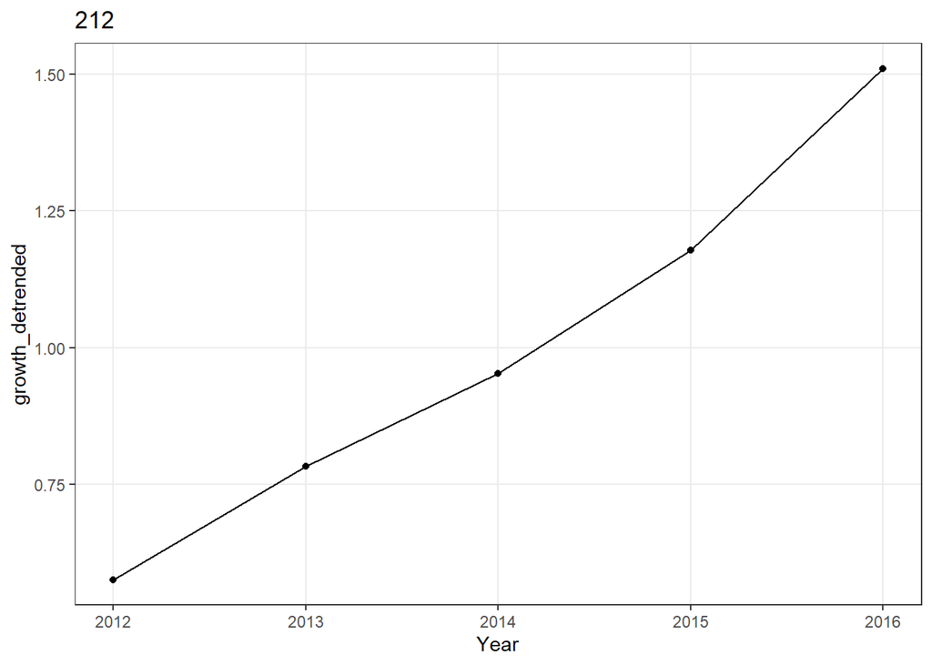

```r
ringplot(212)
```

```r
add2017(212)
```

### 225

```r
look(225)
```

```
## # A tibble: 1 x 7
##   tree  HEIGHT PERC_NEEDLES NEEDLE_COLOR BARK   BUDS   Growing
##   <chr>  <dbl> <chr>        <chr>        <chr>  <chr>  <chr>
## 1 225       31 70           red          intact intact YES
```

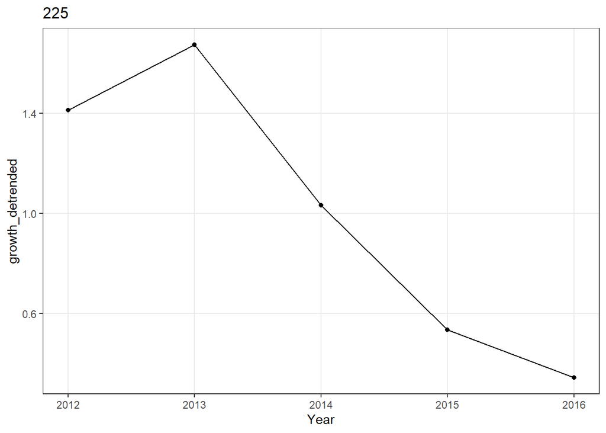

```r
ringplot(225)
```

```r
add2016(225)
```

### 210

```r
look(210)
```

```
## # A tibble: 1 x 7
##   tree  HEIGHT PERC_NEEDLES NEEDLE_COLOR  BARK   BUDS   Growing
##   <chr>  <dbl> <chr>        <chr>         <chr>  <chr>  <chr>
## 1 210       39 99           orange to tan intact intact NO
```

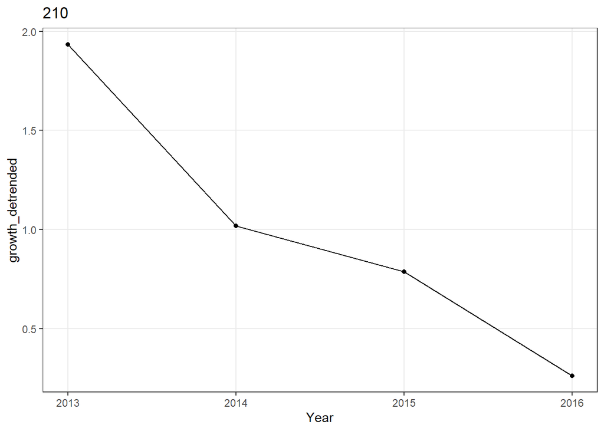

```r
ringplot(210)
```

```r
add2016(210)
```

### 233

```r
look(233)
```

```
## # A tibble: 1 x 7
##   tree  HEIGHT PERC_NEEDLES NEEDLE_COLOR BARK   BUDS       Growing
##   <chr>  <dbl> <chr>        <chr>        <chr>  <chr>      <chr>
## 1 233       22 99           red          intact not formed YES
```

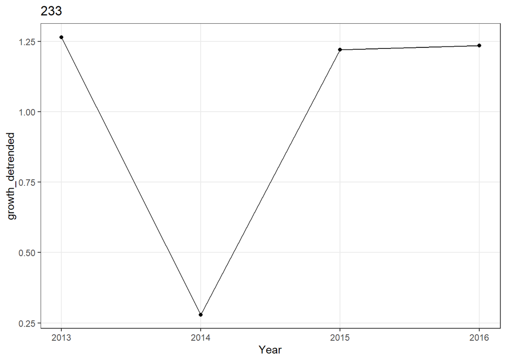

```r
ringplot(233)
```

```r
add2017(233)
```

### 221

```r
look(221)
```

```
## # A tibble: 1 x 7
##   tree  HEIGHT PERC_NEEDLES NEEDLE_COLOR BARK   BUDS   Growing
##   <chr>  <dbl> <chr>        <chr>        <chr>  <chr>  <chr>
## 1 221       18 95           red          intact intact UNKNOWN
```

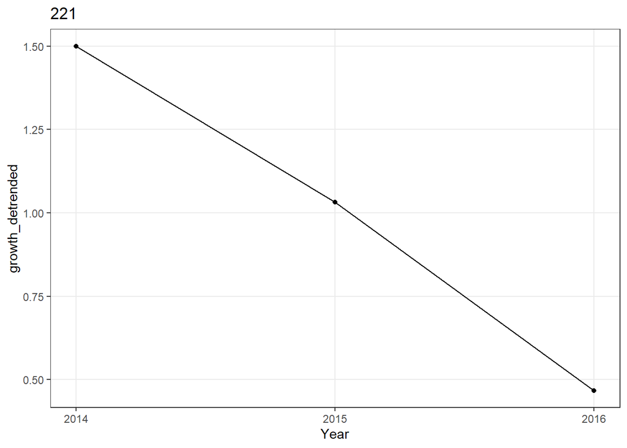

```r
ringplot(221)
```

```r
add2016(221)
```

### 56

```r
look(56)
```

```
## # A tibble: 1 x 7
##   tree  HEIGHT PERC_NEEDLES NEEDLE_COLOR BARK   BUDS   Growing
##   <chr>  <dbl> <chr>        <chr>        <chr>  <chr>  <chr>
## 1 56        88 90           red          intact intact NO
```

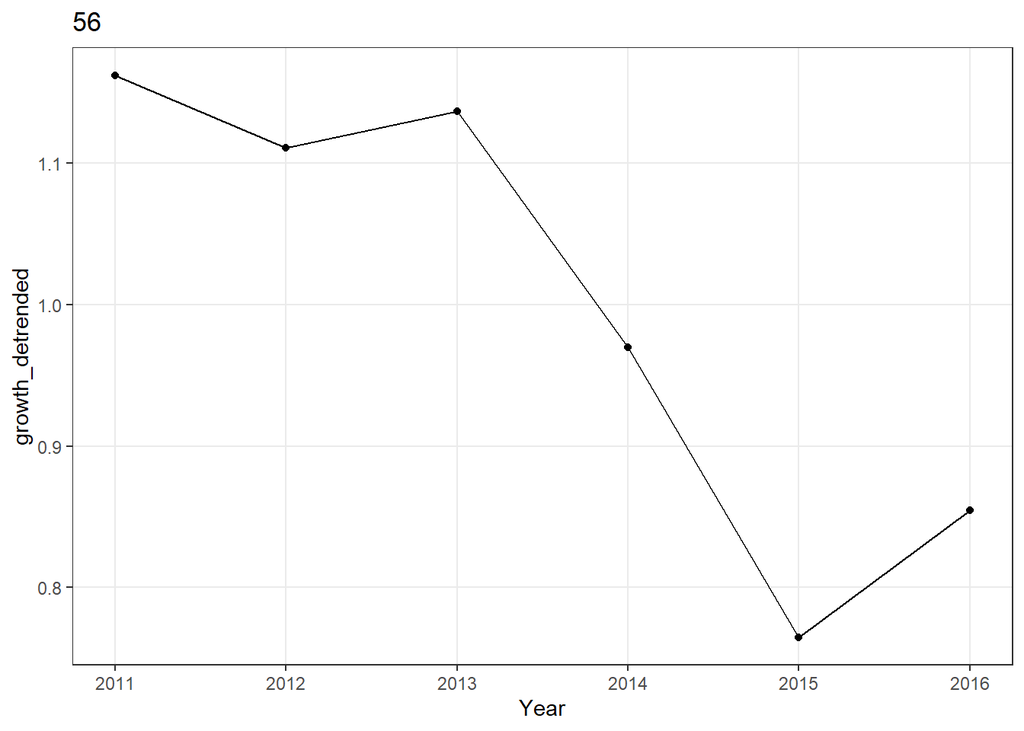

```r
ringplot(56)
```

```r
add2016(56)
```

### 218

```r
look(218)
```

```
## # A tibble: 1 x 7
##   tree  HEIGHT PERC_NEEDLES NEEDLE_COLOR BARK   BUDS    Growing
##   <chr>  <dbl> <chr>        <chr>        <chr>  <chr>   <chr>
## 1 218       31 95           red          intact partial NO
```

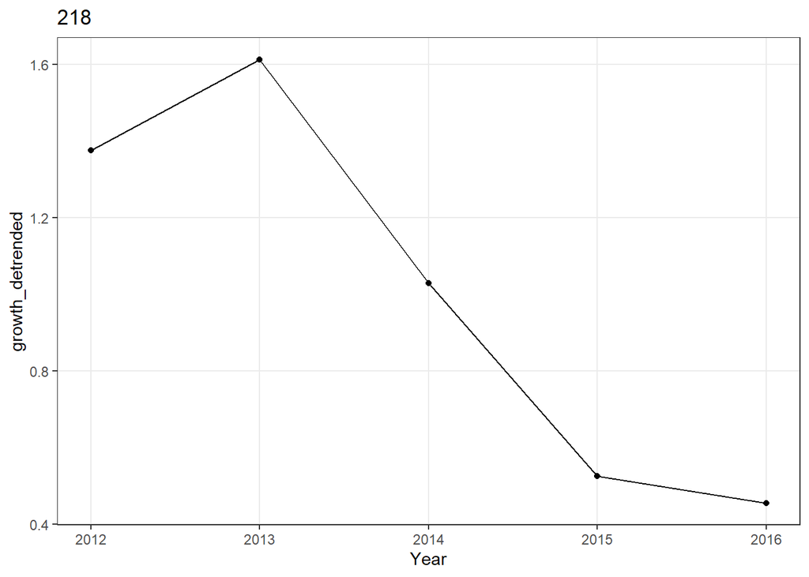

```r
ringplot(218)
```

```r
add2016(218)
```

### 219

```r
look(219)
```

```
## # A tibble: 1 x 7
##   tree  HEIGHT PERC_NEEDLES NEEDLE_COLOR BARK   BUDS   Growing
##   <chr>  <dbl> <chr>        <chr>        <chr>  <chr>  <chr>
## 1 219       48 95           red          intact intact NO
```

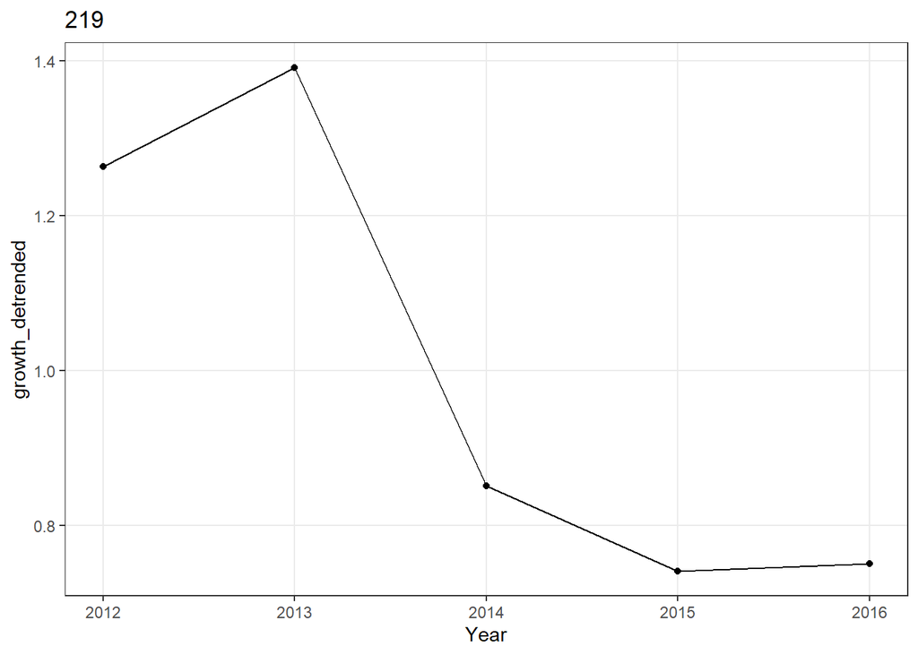

```r
ringplot(219)
```

```r
add2016(219)
```

### 220

```r
look(220)
```

```
## # A tibble: 1 x 7
##   tree  HEIGHT PERC_NEEDLES NEEDLE_COLOR BARK   BUDS   Growing
##   <chr>  <dbl> <chr>        <chr>        <chr>  <chr>  <chr>
## 1 220       35 95           red          intact intact NO
```

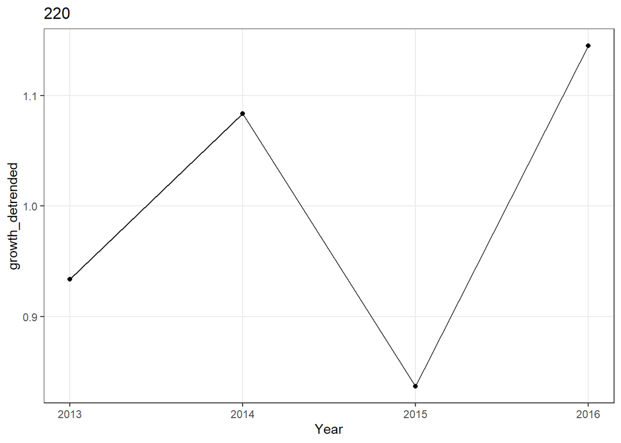

```r
ringplot(220)
```

```r
add2016(220) # based on ppt
```

### 226

```r
look(226)
```

```
## # A tibble: 1 x 7
##   tree  HEIGHT PERC_NEEDLES NEEDLE_COLOR BARK   BUDS   Growing
##   <chr>  <dbl> <chr>        <chr>        <chr>  <chr>  <chr>
## 1 226       20 90           red          intact intact NO
```

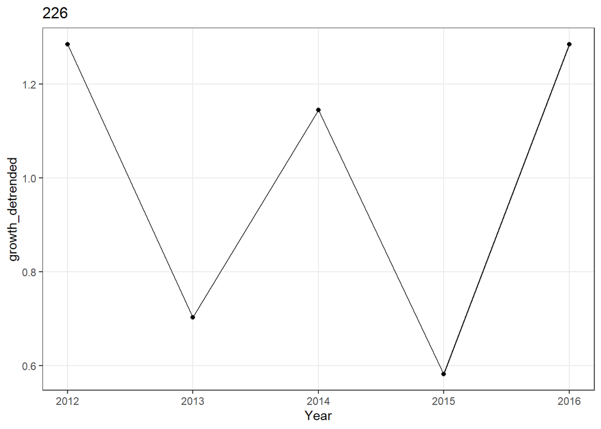

```r
ringplot(226)
```

```r
add2016(226)
```

### 227

```r
look(227)
```

```
## # A tibble: 1 x 7
##   tree  HEIGHT PERC_NEEDLES NEEDLE_COLOR BARK   BUDS       Growing
##   <chr>  <dbl> <chr>        <chr>        <chr>  <chr>      <chr>
## 1 227       35 95           red          intact not intact NO
```

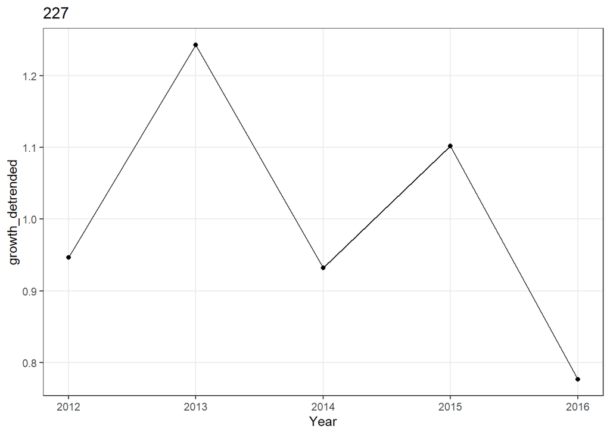

```r
ringplot(227)
```

```r
add2016(227) # ppt
```

### 36

```r
look(36)
```

```
## # A tibble: 1 x 7
##   tree  HEIGHT PERC_NEEDLES NEEDLE_COLOR BARK   BUDS   Growing
##   <chr>  <dbl> <chr>        <chr>        <chr>  <chr>  <chr>
## 1 36        20 90           red          intact intact NO
```

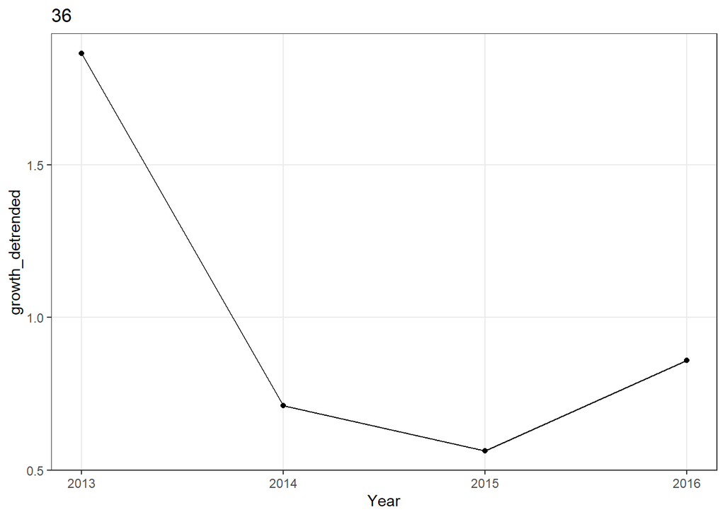

```r
ringplot(36)
```

```r
add2016(36)
```

### 91

```r
look(91)
```

```
## # A tibble: 1 x 7
##   tree  HEIGHT PERC_NEEDLES NEEDLE_COLOR BARK   BUDS   Growing
##   <chr>  <dbl> <chr>        <chr>        <chr>  <chr>  <chr>
## 1 91        20 95           red          intact intact NO
```

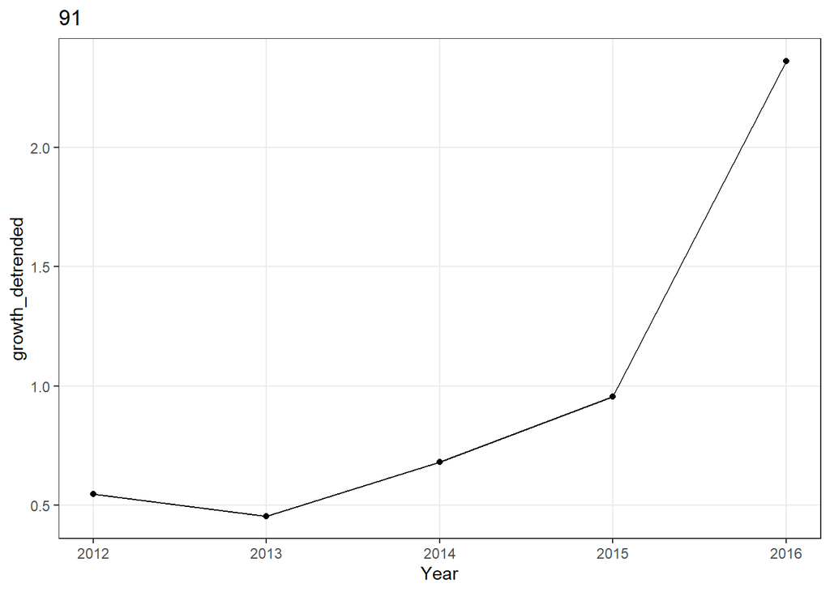

```r
ringplot(91)
```

```r
add2016(91)
```

### 97

```r
look(97)
```

```
## # A tibble: 1 x 7
##   tree  HEIGHT PERC_NEEDLES NEEDLE_COLOR BARK                 BUDS  Growing
##   <chr>  <dbl> <chr>        <chr>        <chr>                <chr> <chr>
## 1 97        17 90           red          cracking on bottom ~ inta~ NO
```

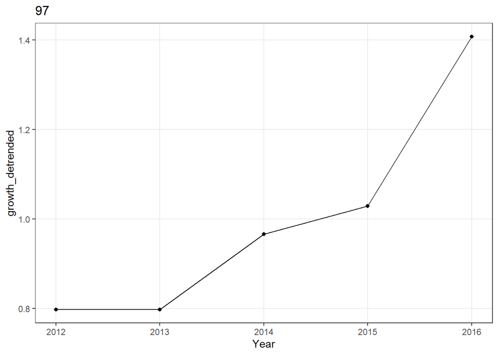

```r
ringplot(97)
```

```r
add2016(97) # based on ppt
```

# Check that everything is accounted for

```r
dfa %>%
  filter(!tree  %in% died2017 & !tree %in% died2016 & !tree %in% died2015) %>%
  dplyr::select(tree) %>%
  distinct() %>%
  arrange(tree)
```

```
## # A tibble: 0 x 1
## # ... with 1 variable: tree <chr>
```

# Count trees in each death year

```r
length(died2017)
```

```
## [1] 28
```

```r
length(died2016)
```

```
## [1] 39
```

```r
length(died2015)
```

```
## [1] 17
```

# Save lists of trees that died in each year

```r
save(died2017, file = "../../results/data/GrowthMortality/died2017_abco.Rdata")
save(died2016, file = "../../results/data/GrowthMortality/died2016_abco.Rdata")
save(died2015, file = "../../results/data/GrowthMortality/died2015_abco.Rdata")
```

## Find duplicates

```r
length(unique(c(died2017, died2016, died2015))) == length(unique(dfa$tree))
```

```
## [1] FALSE
```

# Summarize variables for each year of death

## Percent needles

```r
dfafull %>%
  filter(tree %in% died2017) %>%
  dplyr::select(tree, HEIGHT, PERC_NEEDLES, NEEDLE_COLOR, BARK, BUDS, Growing) %>%
  summarize(median_perc_needles = median(na.omit(as.numeric(PERC_NEEDLES))), mean_perc_needles = mean(na.omit(as.numeric(PERC_NEEDLES))))
```

```
## # A tibble: 1 x 2
##   median_perc_needles mean_perc_needles
##                 <dbl>             <dbl>
## 1                  99              90.6
```

```r
dfafull %>%
  filter(tree %in% died2016) %>%
  dplyr::select(tree, HEIGHT, PERC_NEEDLES, NEEDLE_COLOR, BARK, BUDS, Growing) %>%
  summarize(median_perc_needles = median(na.omit(as.numeric(PERC_NEEDLES))), mean_perc_needles = mean(na.omit(as.numeric(PERC_NEEDLES))))
```

```
## # A tibble: 1 x 2
##   median_perc_needles mean_perc_needles
##                 <dbl>             <dbl>
## 1                  95              92.1
```

```r
dfafull %>%
  filter(tree %in% died2015) %>%
  dplyr::select(tree, HEIGHT, PERC_NEEDLES, NEEDLE_COLOR, BARK, BUDS, Growing) %>%
  summarize(median_perc_needles = median(na.omit(as.numeric(PERC_NEEDLES))), mean_perc_needles = mean(na.omit(as.numeric(PERC_NEEDLES))))
```

```
## # A tibble: 1 x 2
##   median_perc_needles mean_perc_needles
##                 <dbl>             <dbl>
## 1                   2              7.71
```

## Color

```r
dfafull %>%
  filter(tree %in% died2017) %>%
  dplyr::select(tree, NEEDLE_COLOR) %>%
  distinct() %>%
  mutate(NEEDLE_COLOR = tolower(NEEDLE_COLOR)) %>%
  group_by(NEEDLE_COLOR) %>%
  summarize(n())
```

```
## # A tibble: 12 x 2
##    NEEDLE_COLOR                      `n()`
##    <chr>                             <int>
##  1 green, tan, red                       1
##  2 greenish                              1
##  3 light green                           2
##  4 light green to orange                 1
##  5 light green to red                    1
##  6 light green to red or tan             1
##  7 red                                  13
##  8 red-tan                               1
##  9 red to light green                    3
## 10 red to tan                            1
## 11 reddish tan with some light green     1
## 12 tan to light green                    1
```

```r
dfafull %>%
  filter(tree %in% died2016) %>%
  dplyr::select(tree, NEEDLE_COLOR) %>%
  distinct() %>%
  mutate(NEEDLE_COLOR = tolower(NEEDLE_COLOR)) %>%
  group_by(NEEDLE_COLOR) %>%
  summarize(n())
```

```
## # A tibble: 7 x 2
##   NEEDLE_COLOR       `n()`
##   <chr>              <int>
## 1 orange                 1
## 2 orange to tan          1
## 3 red                   31
## 4 red to light brown     1
## 5 red to tan             1
## 6 reddish brown          2
## 7 reddish tan            1
```

```r
dfafull %>%
  filter(tree %in% died2015) %>%
  dplyr::select(tree, NEEDLE_COLOR) %>%
  distinct() %>%
  mutate(NEEDLE_COLOR = tolower(NEEDLE_COLOR)) %>%
  group_by(NEEDLE_COLOR) %>%
  summarize(n())
```

```
## # A tibble: 7 x 2
##   NEEDLE_COLOR `n()`
##   <chr>        <int>
## 1 brown            1
## 2 gray             6
## 3 gray brown       3
## 4 gray/red         1
## 5 grey             3
## 6 red/gray         1
## 7 tan              2
```

## Bark

```r
bark2017 <- dfafull %>%
  filter(tree %in% died2017) %>%
  dplyr::select(tree, BARK) %>%
  distinct() %>%
  mutate(BARK = tolower(BARK)) %>%
  group_by(BARK) %>%
  summarize(n = n())
bark2017[bark2017$BARK=="intact","n"]/sum(bark2017$n)
```

```
##           n
## 1 0.8148148
```

```r
dfafull %>%
  filter(tree %in% died2016) %>%
  dplyr::select(tree, BARK) %>%
  distinct() %>%
  mutate(BARK = tolower(BARK)) %>%
  group_by(BARK) %>%
  summarize(n())
```

```
## # A tibble: 5 x 2
##   BARK                       `n()`
##   <chr>                      <int>
## 1 cracking 20%                   1
## 2 cracking on bottom 3cm         1
## 3 intact                        34
## 4 lightly cracking over 7 cm     1
## 5 small cracks                   1
```

```r
dfafull %>%
  filter(tree %in% died2015) %>%
  dplyr::select(tree, BARK) %>%
  distinct() %>%
  mutate(BARK = tolower(BARK)) %>%
  group_by(BARK) %>%
  summarize(n())
```

```
## # A tibble: 12 x 2
##    BARK                                  `n()`
##    <chr>                                 <int>
##  1 cracked in 2 places                       1
##  2 cracking                                  2
##  3 cracking at base and on some branches     1
##  4 cracking over 100%                        1
##  5 cracking over 15 cm                       1
##  6 crackng everywhere, missing from 8 cm     1
##  7 intact                                    5
##  8 lightly cracking over 14 cm               1
##  9 missing over 5 cm near top                1
## 10 peeling on 1%                             1
## 11 peeling on 15%                            1
## 12 starting to crack                         1
```

## Buds

```r
BUDS2017 <- dfafull %>%
  filter(tree %in% died2017) %>%
  dplyr::select(tree, BUDS) %>%
  distinct() %>%
  mutate(BUDS = tolower(BUDS)) %>%
  group_by(BUDS) %>%
  summarize(n = n())
BUDS2017
```

```
## # A tibble: 6 x 2
##   BUDS                              n
##   <chr>                         <int>
## 1 intact                           18
## 2 none                              1
## 3 not formed                        1
## 4 not formed yet                    1
## 5 not formed; new growth intact     5
## 6 partial                           1
```

```r
BUDS2017[BUDS2017$BUDS=="intact","n"]/sum(BUDS2017$n)
```

```
##           n
## 1 0.6666667
```

```r
dfafull %>%
  filter(tree %in% died2016) %>%
  dplyr::select(tree, BUDS) %>%
  distinct() %>%
  mutate(BUDS = tolower(BUDS)) %>%
  group_by(BUDS) %>%
  summarize(n())
```

```
## # A tibble: 4 x 2
##   BUDS                          `n()`
##   <chr>                         <int>
## 1 intact                           35
## 2 not formed; new growth intact     1
## 3 not intact                        1
## 4 partial                           1
```

```r
dfafull %>%
  filter(tree %in% died2015) %>%
  dplyr::select(tree, BUDS) %>%
  distinct() %>%
  mutate(BUDS = tolower(BUDS)) %>%
  group_by(BUDS) %>%
  summarize(n())
```

```
## # A tibble: 3 x 2
##   BUDS    `n()`
##   <chr>   <int>
## 1 inact       1
## 2 intact     10
## 3 partial     6
```

# Assign time of death in column of dfafull

```r
dfafull <- dfafull %>%
  mutate(time_of_death = ifelse(tree %in% died2017 & Growing == "YES", "2017 growing season", 0))
```

```r
dfafull <- dfafull %>%
  mutate(time_of_death = ifelse(tree %in% c(203), "between 2016 and 2017 growth", time_of_death))
```

## Assign outer ring column

**Note: this was not measured for ring width.** **Also note: can be different from year of death if the tree died before the ring was put on**

# Re-assign death year for best guess of skeleton plot matching, then try plotting master chronology to compare to live tree master chronology

```r
dfatest <- dfa %>%
  filter(tree %in% c(died2017, died2016, died2015)) %>%
  mutate(Year = ifelse(tree %in% died2016, Year-1, Year)) %>%
  mutate(Year = ifelse(tree %in% died2015, Year-2, Year))
head(dfatest)
```

```
## # A tibble: 6 x 3
##   tree   Year growth_detrended
##   <chr> <dbl>            <dbl>
## 1 201    2007            0.763
## 2 41     2007            1.35
## 3 129    2006            1.91
## 4 161    2008            1.04
## 5 201    2008            0.746
## 6 41     2008            1.00
```

# Plot with standard errors*2

```r
dfatest <- dfatest %>%
  filter(Year > 2008) %>%
  group_by(Year) %>%
  mutate(mean_gr_year = mean(growth_detrended)) %>%
  mutate(n_year = n()) %>%
  mutate(stderror = sd(growth_detrended)/sqrt(n_year)) %>%
  mutate(min = mean_gr_year-2*stderror) %>%
  mutate(max = mean_gr_year+2*stderror)
```

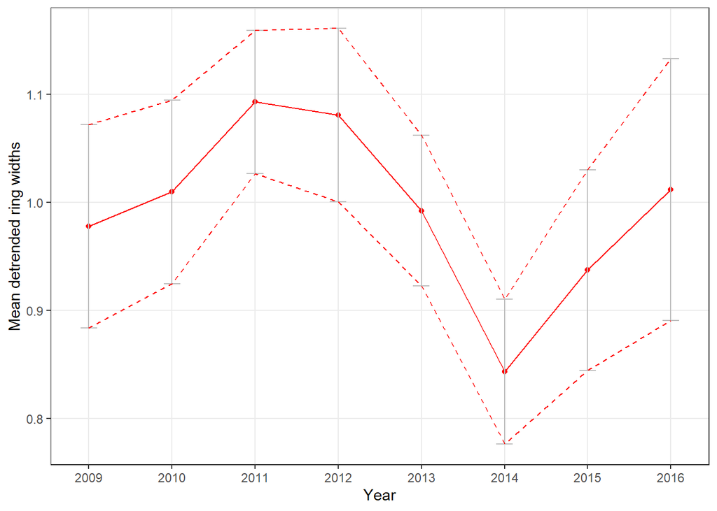

```r
ggplot(data = dfatest, aes(x = Year, y = mean_gr_year))+
  geom_point(col = "red")+
  geom_line(col = "red")+
  geom_errorbar(aes(x = Year,ymin = min, ymax = max), width = .2, col = "gray")+
  geom_line(aes(x = Year, y = min), col = "red", linetype = "dashed")+
  geom_line(aes(x = Year, y = max), col = "red", linetype = "dashed")+
  #ggtitle("Dead ABCO detrended means +/- 2 SE")+
  ylab("Mean detrended ring widths") +
  scale_x_continuous(breaks = seq(min(dfa$Year), max(dfa$Year), by = 1))+
  theme_bw()+
  theme(panel.grid.minor = element_blank(),
        text = element_text(size = 11))
```

```r
ggsave("../../results/figures/GrowthMortality/dead_chron_abco.jpg", width = 3.5, height = 3.5)
```

# Check the shape of 2015 trees since I didn’t have many to base the physical critera on

```r
dfatest2015 <- dfatest %>%
  filter(tree %in% died2015) %>%
  group_by(Year) %>%
  mutate(mean_gr_year = mean(growth_detrended)) %>%
  mutate(n_year = n()) %>%
  mutate(stderror = sd(growth_detrended)/sqrt(n_year)) %>%
  mutate(min = mean_gr_year-2*stderror) %>%
  mutate(max = mean_gr_year+2*stderror)
```

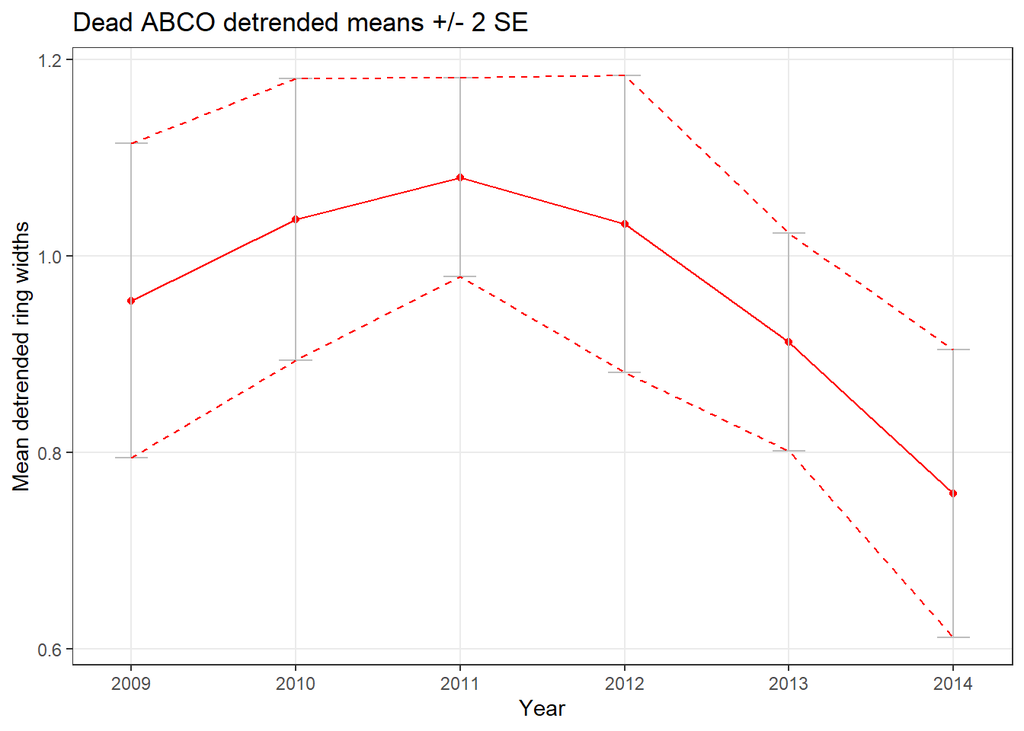

```r
ggplot(data = dfatest2015, aes(x = Year, y = mean_gr_year))+
  geom_point(col = "red")+
  geom_line(col = "red")+
  geom_errorbar(aes(x = Year,ymin = min, ymax = max), width = .2, col = "gray")+
  geom_line(aes(x = Year, y = min), col = "red", linetype = "dashed")+
  geom_line(aes(x = Year, y = max), col = "red", linetype = "dashed")+
  ggtitle("Dead ABCO detrended means +/- 2 SE")+
  ylab("Mean detrended ring widths") +
  scale_x_continuous(breaks = seq(min(dfa$Year), max(dfa$Year), by = 1))+
  theme_bw()+
  theme(panel.grid.minor = element_blank())
```

# Save df version of the detrended dendro data

```r
save(dfa, file = "../../compiled_data/fir_rings_detrended_dead.Rdata")
```

# Summarize detrended dead growth to compare to detrended live growth

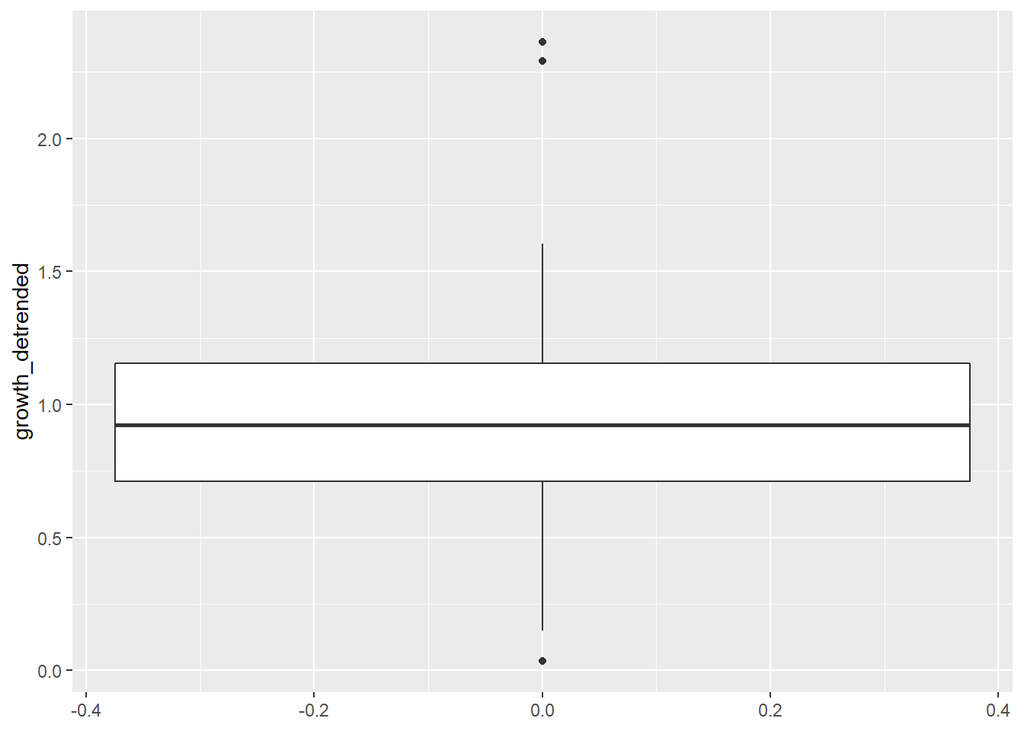

```r
dfa %>%
  filter(Year %in% (c(2014, 2015, 2016))) %>%
  ggplot()+
  geom_boxplot(aes(y = growth_detrended))
```

```r
dfa %>%
  filter(Year %in% (c(2014, 2015, 2016))) %>%
  ungroup() %>%
  summarize(mean(growth_detrended))
```

```
## # A tibble: 1 x 1
##   `mean(growth_detrended)`
##                      <dbl>
## 1                    0.927
```

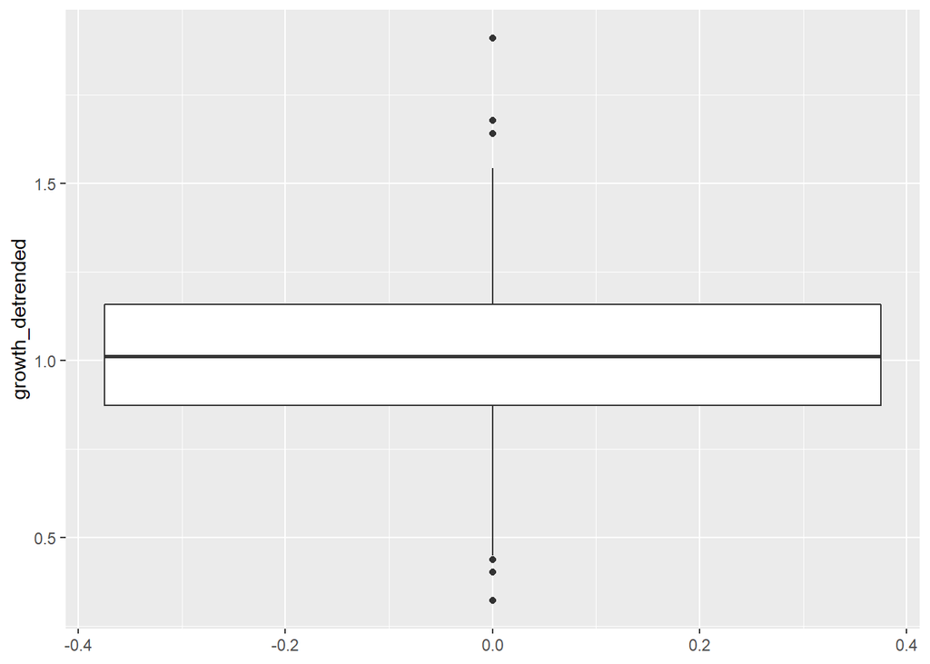

```r
dfp %>%
  filter(Year %in% (c(2014, 2015, 2016))) %>%
  ggplot()+
  geom_boxplot(aes(y = growth_detrended))
```

```r
dfp %>%
  filter(Year %in% (c(2014, 2015, 2016))) %>%
  ungroup() %>%
  summarize(mean(growth_detrended))
```

```
##   mean(growth_detrended)
## 1               1.006669
```

# List trees in each year of death

```r
sort(died2017)
```

```
##  [1]  16  30  32  41  51  52  55  62  93 100 101 112 127 132 137 139 161
## [18] 169 198 201 208 211 212 215 222 223 232 233
```

```r
sort(died2016)
```

```
##  [1] "102"   "111"   "117"   "119"   "131"   "18"    "183-A" "184-A"
##  [9] "192"   "193"   "195"   "199"   "203"   "207"   "210"   "216"
## [17] "218"   "219"   "220"   "221"   "224"   "225"   "226"   "227"
## [25] "230"   "234"   "235"   "29"    "33"    "36"    "4"     "47"
## [33] "56"    "68"    "77"    "78"    "91"    "96"    "97"
```

```r
sort(died2015)
```

```
##  [1] "120" "128" "129" "130" "141" "197" "206" "214" "217" "228" "229"
## [12] "231" "31"  "37"  "66"  "79"  "80"
```

```r
sort(definitely_green)
```

```
##  [1]  16  30  32  52  55 100 127 169 201 208 211 215
```